[figure not shown]

# **Machine Learning II: Classification Foundations & Baseline Models (Hypertension Cohort)**

**Week 3, Day 2 and 3:** Transitioning to Classification, Baseline Algorithms & Evaluation Metrics

## **MACHINE LEARNING**

Machine Learning (ML) is a branch of Artificial Intelligence that enables computers to learn patterns from data and make predictions or decisions without being explicitly programmed. Instead of following fixed rules, machine learning algorithms improve their performance as they are exposed to more data.

### **Why Machine Learning?**

Machine learning is used to analyze large amounts of data, uncover hidden patterns, make predictions, automate decision-making, and improve accuracy in solving real-world problems.

### **Branches of Machine Learning**

**Supervised Learning** uses labeled data, where the correct output is already known. It is mainly used for **classification** (predicting categories such as spam or not spam) and **regression** (predicting continuous values such as house prices).

**Unsupervised Learning** uses unlabeled data to discover hidden structures or patterns. It is commonly applied in clustering, customer segmentation, and association rule mining.

**Semi-Supervised Learning** combines a small amount of labeled data with a large amount of unlabeled data to improve model performance, especially when labeling data is expensive.

**Reinforcement Learning** enables an agent to learn by interacting with its environment and receiving rewards or penalties. It is widely used in robotics, autonomous vehicles, and game-playing systems.

### **Types of Machine Learning Problems**

Machine learning problems are generally classified into **classification**, **regression**, **clustering**, and **anomaly detection**. Classification predicts categories, regression predicts numerical values, clustering groups similar observations, while anomaly detection identifies unusual or suspicious patterns.

### **Applications of Machine Learning**

Machine learning has applications across many fields. In healthcare, it supports disease diagnosis and medical image analysis. In finance, it is used for fraud detection and credit scoring. Businesses use it for customer segmentation, sales forecasting, and recommendation systems. Other applications include agriculture, education, transportation, manufacturing, cybersecurity, and environmental monitoring.

### **Advantages**

Machine learning can process large datasets efficiently, identify complex patterns, improve prediction accuracy, automate repetitive tasks, and support data-driven decision-making.

### **Challenges**

Despite its benefits, machine learning requires high-quality data, significant computational resources, and careful model selection. Poor data quality, overfitting, and biased datasets can reduce model performance.

### **Summary**

Machine learning is a powerful field of Artificial Intelligence that allows computers to learn from data and improve their predictions over time. Its four major branches—supervised, unsupervised, semi-supervised, and reinforcement learning—provide solutions to a wide range of prediction, classification, and pattern recognition problems across numerous industries.

### **STAGE 1: PROBLEM FORMULATION**

**Clinical Objective:** Predict the presence of Hypertension (HTN) in an HIV-positive cohort based on patient demographics, clinical markers, and HIV-related variables to enable early cardiovascular risk stratification and intervention.

**Target Variable:** `HTN` (Binary: 0 = No Hypertension, 1 = Hypertension Present). *Derived using standard clinical thresholds: SBP ≥ 140 mmHg or DBP ≥ 90 mmHg.*

**Real-World Implications:**

- **False Negatives:** Missed hypertension diagnosis → increased risk of stroke, myocardial infarction, and renal failure. **HIGH clinical cost.** (Recall/Sensitivity is prioritized).
- **False Positives:** Unnecessary clinical monitoring or medication side effects. **MODERATE clinical cost.** (Precision balances this).

**Hypotheses:**

1. Tree-based models (like Random Forest or XGBoost) will likely outperform linear models due to non-linear relationships between age, BMI, renal function (`log_creat_centered`), and blood pressure.
2. Key predictors will include `age`, `BMI`, `log_creat_centered`, and `male.gender`.

### **STAGE 2: LIBRARIES, DATA IMPORTATION & EXPLORATORY INSPECTION**

#### **2.1. Load all Required Libraries**

```python
import pandas as pd
import numpy as np
import matplotlib.pyplot as plt
import seaborn as sns
import time
import warnings

from sklearn.model_selection import train_test_split, RandomizedSearchCV, StratifiedKFold
from sklearn.preprocessing import OrdinalEncoder, StandardScaler
from sklearn.impute import SimpleImputer
from sklearn.compose import ColumnTransformer
from sklearn.pipeline import Pipeline
from sklearn.ensemble import RandomForestClassifier
from sklearn.linear_model import LogisticRegression
from sklearn.neighbors import KNeighborsClassifier
from sklearn.svm import SVC
from sklearn.naive_bayes import GaussianNB

from sklearn.metrics import (accuracy_score, precision_score, recall_score, f1_score,
                             roc_auc_score, confusion_matrix, precision_recall_curve, auc)
```

> **`Fix all randomness for full reproducibility`**

```python
SEED = 42
np.random.seed(SEED)
warnings.filterwarnings('ignore')
```

#### **2.2. Load and Preprocess the Data**

> **`Load data, treating common missing value indicators as NaN`**

```python
df = pd.read_csv("htn_dat.csv", na_values=["NA", "?", "NaN", ""])
df.head()
```

|  | ID | DBP | SBP | BMI | age | married | male.gender | hgb_centered | adv_HIV | survtime | event | arv_naive | urban.clinic | log_creat_centered | IPW_weight | SBP_ge120 |
| --- | --- | --- | --- | --- | --- | --- | --- | --- | --- | --- | --- | --- | --- | --- | --- | --- |
| 0 | 16097 | 60 | 90 | NaN | 28.000000 | 0.0 | 0 | NaN | NaN | 338 | 1 | 1 | 0 | NaN | 0.924379 | 0 |
| 1 | 930 | 75 | 110 | 27.339912 | 26.458590 | 1.0 | 0 | -3.9 | 0.0 | 439 | 1 | 1 | 1 | 5.421770e-02 | 1.163862 | 0 |
| 2 | 6877 | 60 | 80 | 17.689789 | 42.951405 | 0.0 | 0 | -3.2 | NaN | 752 | 1 | 1 | 0 | -3.597409e-01 | 0.721148 | 0 |
| 3 | 36464 | 60 | 90 | 19.854080 | 50.149212 | 1.0 | 1 | NaN | NaN | 526 | 1 | 1 | 1 | NaN | 0.829452 | 0 |
| 4 | 36180 | 60 | 100 | 21.295294 | 30.554415 | 0.0 | 1 | -0.4 | NaN | 215 | 1 | 1 | 0 | -1.000000e-07 | 0.856046 | 0 |

> **`1. Create Target Variable: Hypertension (SBP >= 140 or DBP >= 90)`**

```python
df['HTN'] = ((df['SBP'] >= 140) | (df['DBP'] >= 90)).astype(int)
```

> **`2. Drop ID, raw BP values (since they define the target), survival outcomes, and weights`**

```python
cols_to_drop = ['ID', 'SBP', 'DBP', 'survtime', 'event', 'IPW_weight']
```

> **`Safely drop columns that exist`**

```python
df = df.drop(columns=[col for col in cols_to_drop if col in df.columns])
```

> **`Drop any potential mangled/extra columns from CSV parsing issues (keep only known clinical vars)`**

```python
valid_cols = ['BMI', 'age', 'married', 'male.gender', 'hgb_centered',
              'adv_HIV', 'arv_naive', 'urban.clinic', 'log_creat_centered', 'HTN']
df = df[[col for col in valid_cols if col in df.columns]]

df.head()
```

|  | BMI | age | married | male.gender | hgb_centered | adv_HIV | arv_naive | urban.clinic | log_creat_centered | HTN |
| --- | --- | --- | --- | --- | --- | --- | --- | --- | --- | --- |
| 0 | NaN | 28.000000 | 0.0 | 0 | NaN | NaN | 1 | 0 | NaN | 0 |
| 1 | 27.339912 | 26.458590 | 1.0 | 0 | -3.9 | 0.0 | 1 | 1 | 5.421770e-02 | 0 |
| 2 | 17.689789 | 42.951405 | 0.0 | 0 | -3.2 | NaN | 1 | 0 | -3.597409e-01 | 0 |
| 3 | 19.854080 | 50.149212 | 1.0 | 1 | NaN | NaN | 1 | 1 | NaN | 0 |
| 4 | 21.295294 | 30.554415 | 0.0 | 1 | -0.4 | NaN | 1 | 0 | -1.000000e-07 | 0 |

### **STAGE 3: DATA EXPLORATION**

#### **3.1. Variables Names, Definition and Measurements**

| Variable | Definition | Type | Clinical Relevance |
| --- | --- | --- | --- |
| **age** | Patient's age in years | Continuous | Strong predictor of cardiovascular risk and arterial stiffness. |
| **male.gender** | Biological sex | Binary | Men often have different HTN prevalence and risk profiles. |
| **married** | Marital status | Binary | Socioeconomic/demographic proxy. |
| **BMI** | Body Mass Index | Continuous | Obesity is a primary modifiable risk factor for HTN. |
| **hgb_centered** | Centered Hemoglobin | Continuous | Anemia/polycythemia can relate to cardiovascular/renal health. |
| **adv_HIV** | Advanced HIV disease | Binary | Advanced immunosuppression may affect vascular health. |
| **arv_naive** | Antiretroviral naive | Binary | ART exposure can influence metabolic and cardiovascular risk. |
| **urban.clinic** | Clinic location (Urban) | Binary | Urban vs rural lifestyle and dietary differences. |
| **log_creat_centered** | Centered Log Creatinine | Continuous | Marker of kidney function; closely tied to HTN and renal disease. |
| **HTN (Target)** | Hypertension status | Binary | Derived as 1 if SBP ≥ 140 or DBP ≥ 90, else 0. |

#### **3.2. Check the Distribution of the Target Variable**

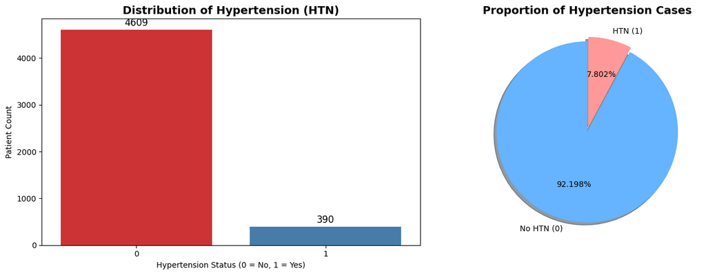

```python
fig, axes = plt.subplots(1, 2, figsize=(14, 5))

# A. Countplot
sns.countplot(x='HTN', data=df, ax=axes[0], palette='Set1')
axes[0].set_title('Distribution of Hypertension (HTN)', fontsize=14, fontweight='bold')
axes[0].set_xlabel('Hypertension Status (0 = No, 1 = Yes)')
axes[0].set_ylabel('Patient Count')

# Add count labels on top of bars
for p in axes[0].patches:
    axes[0].annotate(f'{int(p.get_height())}', (p.get_x() + p.get_width() / 2., p.get_height()),
                     ha='center', va='baseline', fontsize=12, color='black', xytext=(0, 5),
                     textcoords='offset points')

# B. Pie Chart
htn_counts = df['HTN'].value_counts()
axes[1].pie(htn_counts, labels=['No HTN (0)', 'HTN (1)'], autopct='%1.3f%%',
            colors=['#66b3ff', '#ff9999'], startangle=90, explode=(0, 0.05), shadow=True)
axes[1].set_title('Proportion of Hypertension Cases', fontsize=14, fontweight='bold')

plt.tight_layout()
plt.show()
```

#### **3.3. Extract the Target Variable and the Features**

```python
X = df.drop(columns=["HTN"])
y = df["HTN"]
```

> **`Grouping features`**

```python
num_features = ["age", "BMI", "hgb_centered", "log_creat_centered"]
cat_features = ["married", "male.gender", "adv_HIV", "arv_naive", "urban.clinic"]
```

> **`Filter to ensure we only use columns that successfully loaded`**

```python
num_features = [f for f in num_features if f in X.columns]
cat_features = [f for f in cat_features if f in X.columns]
```

### **STAGE 4: DATA PREPROCESSING AND ML PIPELINE CREATION**

#### **4.1. Numeric & Categorical Pipelines**

```python
numeric_transformer = Pipeline(steps=[
    ('imputer', SimpleImputer(strategy='median')),
    ('scaler', StandardScaler())
])

categorical_transformer = Pipeline(steps=[
    ('imputer', SimpleImputer(strategy='most_frequent')),
    ('encoder', OrdinalEncoder(handle_unknown='use_encoded_value', unknown_value=-1))
])

preprocessor = ColumnTransformer(
    transformers=[
        ('num', numeric_transformer, num_features),
        ('cat', categorical_transformer, cat_features)
    ])
```

### **STAGE 5: DATA PARTITIONING**

#### **5.1. Conduct the Actual Data Partitioning**

```python
X_train, X_test, y_train, y_test = train_test_split(X, y,
                                                    test_size=0.2,
                                                    random_state=SEED,
                                                    stratify=y)

print(f"Training Set: {X_train.shape[0]}| Class Distribution: {y_train.value_counts().to_dict()}")
print(f"Testing Set: {X_test.shape[0]}| Class Distribution: {y_test.value_counts().to_dict()}")
```

```
Training Set: 3999| Class Distribution: {0: 3687, 1: 312}
Testing Set: 1000| Class Distribution: {0: 922, 1: 78}
```

### **STAGE 6: MODEL TRAINING AND HYPERPARAMETER TUNING**

#### **6.1. Create the Model Training Pipelines**

```python
pos_weight_train = (y_train == 0).sum() / (y_train == 1).sum()

lr_pipeline = Pipeline(steps=[
    ('preprocessor', preprocessor),
    ('lr', LogisticRegression(random_state=SEED, max_iter=1000, class_weight='balanced'))
])

knn_pipeline = Pipeline(steps=[
    ('preprocessor', preprocessor),
    ('knn', KNeighborsClassifier())
])

svm_pipeline = Pipeline(steps=[
    ('preprocessor', preprocessor),
    ('svm', SVC(random_state=SEED, probability=True, class_weight='balanced'))
])

nb_pipeline = Pipeline(steps=[
    ('preprocessor', preprocessor),
    ('nb', GaussianNB())
])
```

#### **6.2. Creating the Hyperparameter GridSearch**

```python
param_dist_lr = {
    'lr__C': [0.01, 0.1, 1, 10, 100],
    'lr__penalty': ['l1', 'l2', 'elasticnet', 'none'],
    'lr__solver': ['newton-cg', 'lbfgs', 'liblinear', 'sag', 'saga']
}

param_dist_knn = {
    'knn__n_neighbors': [3, 5, 7, 9, 11],
    'knn__weights': ['uniform', 'distance'],
    'knn__metric': ['euclidean', 'manhattan', 'minkowski']
}

param_dist_svm = {
    'svm__C': [0.1, 1, 10, 100],
    'svm__kernel': ['linear', 'poly', 'rbf', 'sigmoid'],
    'svm__gamma': ['scale', 'auto']
}

param_dist_nb = {
    'nb__var_smoothing': [1e-09, 1e-08, 1e-07, 1e-06, 1e-05]
}
```

#### **6.3. Actual Model Training**

```python
cv = StratifiedKFold(n_splits=5, shuffle=True, random_state=SEED)
print("⏳️ Starting RandomizedSearchCV (n_iter=30, 5-Fold Stratified)...")

results = {}
training_times = {}

all_pipelines = [
    ('Logistic Regression', lr_pipeline, param_dist_lr),
    ('KNN', knn_pipeline, param_dist_knn),
    ('SVM', svm_pipeline, param_dist_svm),
    ('Naive Bayes', nb_pipeline, param_dist_nb)
]

for name, pipeline, params in all_pipelines:
    start = time.time()
    search = RandomizedSearchCV(
        estimator=pipeline,
        param_distributions=params,
        n_iter=30,
        cv=cv,
        scoring='roc_auc',
        n_jobs=-1,
        random_state=SEED,
        refit=True
    )
    search.fit(X_train, y_train)
    training_times[name] = time.time() - start
    results[name] = search
    print(f"✅ {name} trained. Best ROC-AUC: {search.best_score_:.4f}| Time: {training_times[name]:.2f}s")
```

```
⏳️ Starting RandomizedSearchCV (n_iter=30, 5-Fold Stratified)...
✅ Logistic Regression trained. Best ROC-AUC: 0.6810| Time: 11.97s
✅ KNN trained. Best ROC-AUC: 0.6212| Time: 3.10s
✅ SVM trained. Best ROC-AUC: 0.6789| Time: 323.88s
✅ Naive Bayes trained. Best ROC-AUC: 0.6571| Time: 0.45s
```

### **STAGE 7: MODEL EVALUATION**

#### **7.1. Hold Out (Testing Set) Cross Validation**

```python
print("\n" + "="*110)
print("HOLD-OUT TEST SET EVALUATION")
print("="*110)

eval_metrics = {}
for name, search in results.items():
    model = search.best_estimator_
    y_pred = model.predict(X_test)
    y_prob = model.predict_proba(X_test)[:, 1]

    metrics = {
        'Accuracy': accuracy_score(y_test, y_pred),
        'Precision': precision_score(y_test, y_pred),
        'Recall': recall_score(y_test, y_pred),
        'F1-Score': f1_score(y_test, y_pred),
        'ROC-AUC': roc_auc_score(y_test, y_prob)
    }

    # Precision-Recall AUC (crucial for imbalanced/clinical tasks)
    prec, rec, _ = precision_recall_curve(y_test, y_prob)
    metrics['PR-AUC'] = auc(rec, prec)

    eval_metrics[name] = {**metrics, 'y_pred': y_pred, 'y_prob': y_prob, 'model': model}

    print(f"\n📊 {name}")
    for k, v in metrics.items():
        print(f"  {k:<12}: {v:.4f}")
    print("Confusion Matrix:")
    print(confusion_matrix(y_test, y_pred))
```

```
==============================================================================================================
HOLD-OUT TEST SET EVALUATION
==============================================================================================================

📊 Logistic Regression
  Accuracy    : 0.6770
  Precision   : 0.1470
  Recall      : 0.6538
  F1-Score    : 0.2400
  ROC-AUC     : 0.7175
  PR-AUC      : 0.1650
Confusion Matrix:
[[626 296]
 [ 27  51]]

📊 KNN
  Accuracy    : 0.9200
  Precision   : 0.0000
  Recall      : 0.0000
  F1-Score    : 0.0000
  ROC-AUC     : 0.5425
  PR-AUC      : 0.0884
Confusion Matrix:
[[920   2]
 [ 78   0]]

📊 SVM
  Accuracy    : 0.8120
  Precision   : 0.1333
  Recall      : 0.2564
  F1-Score    : 0.1754
  ROC-AUC     : 0.6822
  PR-AUC      : 0.1405
Confusion Matrix:
[[792 130]
 [ 58  20]]

📊 Naive Bayes
  Accuracy    : 0.9040
  Precision   : 0.1250
  Recall      : 0.0385
  F1-Score    : 0.0588
  ROC-AUC     : 0.6866
  PR-AUC      : 0.1288
Confusion Matrix:
[[901  21]
 [ 75   3]]
```

#### **7.2. Convert the Dictionary to a Data Frame**

```python
results_df = pd.DataFrame({
    model_name: {
        'Accuracy': metrics['Accuracy'],
        'Precision': metrics['Precision'],
        'Recall': metrics['Recall'],
        'F1-Score': metrics['F1-Score'],
        'ROC-AUC': metrics['ROC-AUC'],
        'PR-AUC': metrics['PR-AUC']
    }
    for model_name, metrics in eval_metrics.items()
})

results_df = results_df.round(4)
display(results_df)
```

|  | Logistic Regression | KNN | SVM | Naive Bayes |
| --- | --- | --- | --- | --- |
| Accuracy | 0.6770 | 0.9200 | 0.8120 | 0.9040 |
| Precision | 0.1470 | 0.0000 | 0.1333 | 0.1250 |
| Recall | 0.6538 | 0.0000 | 0.2564 | 0.0385 |
| F1-Score | 0.2400 | 0.0000 | 0.1754 | 0.0588 |
| ROC-AUC | 0.7175 | 0.5425 | 0.6822 | 0.6866 |
| PR-AUC | 0.1650 | 0.0884 | 0.1405 | 0.1288 |

### **STAGE 8: SINGLE TREE-BASED MODEL AND ENSEMBLE MODELS**